# # PART 1

# EDA & Data Preprocessing on Google App Store Rating Dataset.

#### Domain: Mobile device apps

**Context:**

##### The Play Store apps data has enormous potential to drive app-making businesses to success. However, many apps are being developed every single day and only a few of them become profitable. It is important for developers to be able to predict the success of their app and incorporate features which makes an app successful. Before any such predictive-study can be done, it is necessary to do EDA and data-preprocessing on the apps data available for google app store applications. From the collected apps data and user ratings from the app stores.

### Data set Information:

Web scraped data of 10k Play Store apps for analyzing the Android market. Each app (row) has values for category, rating, size, and more.

### Attribute Information:

Slno. Attribute Description

1. App :Application name
2. Category :Category the app belongs to
3. Rating :Overall user rating of the app
4. Size :Size of the app
5. Installs :Number of user reviews for the app
6. Type :Paid or Free
7. Price :Price of the app
8. Content Rating :Age group the app is targeted at - children/Mature 21+ /Adult
9. Genres : An app can belong to multiple genres (apart from its main category). For eg. amusical family game will belong to Music, Game, Family genres.
10. Last Updated : Date when the app was last updated on play store.
11. Current Ver :Current version of the app available on play store.
12. Android Ver :Min required Android Version.

### Questions:-

### 1. Import required libraries and read the dataset?

```python
import pandas as pd
import numpy as np
from matplotlib  import pyplot as plt
import seaborn as sns
%matplotlib inline
from warnings import filterwarnings
filterwarnings("ignore")
```

```python
data=pd.read_csv(r"C:\Users\payal jena\Downloads\Apps_data+(1).csv")
```

```python
data
```

|  | App | Category | Rating | Reviews | Size | Installs | Type | Price | Content Rating | Genres | Last Updated | Current Ver | Android Ver |
| --- | --- | --- | --- | --- | --- | --- | --- | --- | --- | --- | --- | --- | --- |
| 0 | Photo Editor & Candy Camera & Grid & ScrapBook | ART_AND_DESIGN | 4.1 | 159 | 19M | 10,000+ | Free | 0 | Everyone | Art & Design | January 7, 2018 | 1.0.0 | 4.0.3 and up |
| 1 | Coloring book moana | ART_AND_DESIGN | 3.9 | 967 | 14M | 500,000+ | Free | 0 | Everyone | Art & Design;Pretend Play | January 15, 2018 | 2.0.0 | 4.0.3 and up |
| 2 | U Launcher Lite – FREE Live Cool Themes, Hide ... | ART_AND_DESIGN | 4.7 | 87510 | 8.7M | 5,000,000+ | Free | 0 | Everyone | Art & Design | August 1, 2018 | 1.2.4 | 4.0.3 and up |
| 3 | Sketch - Draw & Paint | ART_AND_DESIGN | 4.5 | 215644 | 25M | 50,000,000+ | Free | 0 | Teen | Art & Design | June 8, 2018 | Varies with device | 4.2 and up |
| 4 | Pixel Draw - Number Art Coloring Book | ART_AND_DESIGN | 4.3 | 967 | 2.8M | 100,000+ | Free | 0 | Everyone | Art & Design;Creativity | June 20, 2018 | 1.1 | 4.4 and up |
| ... | ... | ... | ... | ... | ... | ... | ... | ... | ... | ... | ... | ... | ... |
| 10836 | Sya9a Maroc - FR | FAMILY | 4.5 | 38 | 53M | 5,000+ | Free | 0 | Everyone | Education | July 25, 2017 | 1.48 | 4.1 and up |
| 10837 | Fr. Mike Schmitz Audio Teachings | FAMILY | 5.0 | 4 | 3.6M | 100+ | Free | 0 | Everyone | Education | July 6, 2018 | 1.0 | 4.1 and up |
| 10838 | Parkinson Exercices FR | MEDICAL | NaN | 3 | 9.5M | 1,000+ | Free | 0 | Everyone | Medical | January 20, 2017 | 1.0 | 2.2 and up |
| 10839 | The SCP Foundation DB fr nn5n | BOOKS_AND_REFERENCE | 4.5 | 114 | Varies with device | 1,000+ | Free | 0 | Mature 17+ | Books & Reference | January 19, 2015 | Varies with device | Varies with device |
| 10840 | iHoroscope - 2018 Daily Horoscope & Astrology | LIFESTYLE | 4.5 | 398307 | 19M | 10,000,000+ | Free | 0 | Everyone | Lifestyle | July 25, 2018 | Varies with device | Varies with device |

10841 rows × 13 columns

### 2.Check the first few samples, shape, info of the data and try to familiarize yourself with different features?

```python
data.head()
```

|  | App | Category | Rating | Reviews | Size | Installs | Type | Price | Content Rating | Genres | Last Updated | Current Ver | Android Ver |
| --- | --- | --- | --- | --- | --- | --- | --- | --- | --- | --- | --- | --- | --- |
| 0 | Photo Editor & Candy Camera & Grid & ScrapBook | ART_AND_DESIGN | 4.1 | 159 | 19M | 10,000+ | Free | 0 | Everyone | Art & Design | January 7, 2018 | 1.0.0 | 4.0.3 and up |
| 1 | Coloring book moana | ART_AND_DESIGN | 3.9 | 967 | 14M | 500,000+ | Free | 0 | Everyone | Art & Design;Pretend Play | January 15, 2018 | 2.0.0 | 4.0.3 and up |
| 2 | U Launcher Lite – FREE Live Cool Themes, Hide ... | ART_AND_DESIGN | 4.7 | 87510 | 8.7M | 5,000,000+ | Free | 0 | Everyone | Art & Design | August 1, 2018 | 1.2.4 | 4.0.3 and up |
| 3 | Sketch - Draw & Paint | ART_AND_DESIGN | 4.5 | 215644 | 25M | 50,000,000+ | Free | 0 | Teen | Art & Design | June 8, 2018 | Varies with device | 4.2 and up |
| 4 | Pixel Draw - Number Art Coloring Book | ART_AND_DESIGN | 4.3 | 967 | 2.8M | 100,000+ | Free | 0 | Everyone | Art & Design;Creativity | June 20, 2018 | 1.1 | 4.4 and up |

```python
data.shape
```

```
(10841, 13)
```

```python
data.info()
```

```
<class 'pandas.core.frame.DataFrame'>
RangeIndex: 10841 entries, 0 to 10840
Data columns (total 13 columns):
 #   Column          Non-Null Count  Dtype
---  ------          --------------  -----
 0   App             10841 non-null  object
 1   Category        10841 non-null  object
 2   Rating          9367 non-null   float64
 3   Reviews         10841 non-null  object
 4   Size            10841 non-null  object
 5   Installs        10841 non-null  object
 6   Type            10840 non-null  object
 7   Price           10841 non-null  object
 8   Content Rating  10840 non-null  object
 9   Genres          10841 non-null  object
 10  Last Updated    10841 non-null  object
 11  Current Ver     10833 non-null  object
 12  Android Ver     10838 non-null  object
dtypes: float64(1), object(12)
memory usage: 1.1+ MB
```

### 3. Check summary statistics of the dataset. List out the columns that need to be worked upon for model building.

```python
data.describe()
```

|  | Rating |
| --- | --- |
| count | 9367.000000 |
| mean | 4.193338 |
| std | 0.537431 |
| min | 1.000000 |
| 25% | 4.000000 |
| 50% | 4.300000 |
| 75% | 4.500000 |
| max | 19.000000 |

```python
# List out the columns that need to be worked upon for mode building
columns_to_work_on = ['Rating', 'Reviews', 'Size', 'Installs', 'Type', 'Price', 'Content Rating', 'Genres']

# Get summary statistics of the columns to work on
data[columns_to_work_on].describe()
```

|  | Rating |
| --- | --- |
| count | 9367.000000 |
| mean | 4.193338 |
| std | 0.537431 |
| min | 1.000000 |
| 25% | 4.000000 |
| 50% | 4.300000 |
| 75% | 4.500000 |
| max | 19.000000 |

### 4. Check if there are any duplicate records in the dataset? if any drop them.

```python
# Check for duplicates
duplicate_rows = data[data.duplicated() ]
```

```python
duplicate_rows
```

|  | App | Category | Rating | Reviews | Size | Installs | Type | Price | Content Rating | Genres | Last Updated | Current Ver | Android Ver |
| --- | --- | --- | --- | --- | --- | --- | --- | --- | --- | --- | --- | --- | --- |
| 229 | Quick PDF Scanner + OCR FREE | BUSINESS | 4.2 | 80805 | Varies with device | 5,000,000+ | Free | 0 | Everyone | Business | February 26, 2018 | Varies with device | 4.0.3 and up |
| 236 | Box | BUSINESS | 4.2 | 159872 | Varies with device | 10,000,000+ | Free | 0 | Everyone | Business | July 31, 2018 | Varies with device | Varies with device |
| 239 | Google My Business | BUSINESS | 4.4 | 70991 | Varies with device | 5,000,000+ | Free | 0 | Everyone | Business | July 24, 2018 | 2.19.0.204537701 | 4.4 and up |
| 256 | ZOOM Cloud Meetings | BUSINESS | 4.4 | 31614 | 37M | 10,000,000+ | Free | 0 | Everyone | Business | July 20, 2018 | 4.1.28165.0716 | 4.0 and up |
| 261 | join.me - Simple Meetings | BUSINESS | 4.0 | 6989 | Varies with device | 1,000,000+ | Free | 0 | Everyone | Business | July 16, 2018 | 4.3.0.508 | 4.4 and up |
| ... | ... | ... | ... | ... | ... | ... | ... | ... | ... | ... | ... | ... | ... |
| 8643 | Wunderlist: To-Do List & Tasks | PRODUCTIVITY | 4.6 | 404610 | Varies with device | 10,000,000+ | Free | 0 | Everyone | Productivity | April 6, 2018 | Varies with device | Varies with device |
| 8654 | TickTick: To Do List with Reminder, Day Planner | PRODUCTIVITY | 4.6 | 25370 | Varies with device | 1,000,000+ | Free | 0 | Everyone | Productivity | August 6, 2018 | Varies with device | Varies with device |
| 8658 | ColorNote Notepad Notes | PRODUCTIVITY | 4.6 | 2401017 | Varies with device | 100,000,000+ | Free | 0 | Everyone | Productivity | June 27, 2018 | Varies with device | Varies with device |
| 10049 | Airway Ex - Intubate. Anesthetize. Train. | MEDICAL | 4.3 | 123 | 86M | 10,000+ | Free | 0 | Everyone | Medical | June 1, 2018 | 0.6.88 | 5.0 and up |
| 10768 | AAFP | MEDICAL | 3.8 | 63 | 24M | 10,000+ | Free | 0 | Everyone | Medical | June 22, 2018 | 2.3.1 | 5.0 and up |

483 rows × 13 columns

```python
# Drop duplicates
data = data.drop_duplicates()
```

```python
data
```

|  | App | Category | Rating | Reviews | Size | Installs | Type | Price | Content Rating | Genres | Last Updated | Current Ver | Android Ver |
| --- | --- | --- | --- | --- | --- | --- | --- | --- | --- | --- | --- | --- | --- |
| 0 | Photo Editor & Candy Camera & Grid & ScrapBook | ART_AND_DESIGN | 4.1 | 159 | 19M | 10,000+ | Free | 0 | Everyone | Art & Design | January 7, 2018 | 1.0.0 | 4.0.3 and up |
| 1 | Coloring book moana | ART_AND_DESIGN | 3.9 | 967 | 14M | 500,000+ | Free | 0 | Everyone | Art & Design;Pretend Play | January 15, 2018 | 2.0.0 | 4.0.3 and up |
| 2 | U Launcher Lite – FREE Live Cool Themes, Hide ... | ART_AND_DESIGN | 4.7 | 87510 | 8.7M | 5,000,000+ | Free | 0 | Everyone | Art & Design | August 1, 2018 | 1.2.4 | 4.0.3 and up |
| 3 | Sketch - Draw & Paint | ART_AND_DESIGN | 4.5 | 215644 | 25M | 50,000,000+ | Free | 0 | Teen | Art & Design | June 8, 2018 | Varies with device | 4.2 and up |
| 4 | Pixel Draw - Number Art Coloring Book | ART_AND_DESIGN | 4.3 | 967 | 2.8M | 100,000+ | Free | 0 | Everyone | Art & Design;Creativity | June 20, 2018 | 1.1 | 4.4 and up |
| ... | ... | ... | ... | ... | ... | ... | ... | ... | ... | ... | ... | ... | ... |
| 10836 | Sya9a Maroc - FR | FAMILY | 4.5 | 38 | 53M | 5,000+ | Free | 0 | Everyone | Education | July 25, 2017 | 1.48 | 4.1 and up |
| 10837 | Fr. Mike Schmitz Audio Teachings | FAMILY | 5.0 | 4 | 3.6M | 100+ | Free | 0 | Everyone | Education | July 6, 2018 | 1.0 | 4.1 and up |
| 10838 | Parkinson Exercices FR | MEDICAL | NaN | 3 | 9.5M | 1,000+ | Free | 0 | Everyone | Medical | January 20, 2017 | 1.0 | 2.2 and up |
| 10839 | The SCP Foundation DB fr nn5n | BOOKS_AND_REFERENCE | 4.5 | 114 | Varies with device | 1,000+ | Free | 0 | Mature 17+ | Books & Reference | January 19, 2015 | Varies with device | Varies with device |
| 10840 | iHoroscope - 2018 Daily Horoscope & Astrology | LIFESTYLE | 4.5 | 398307 | 19M | 10,000,000+ | Free | 0 | Everyone | Lifestyle | July 25, 2018 | Varies with device | Varies with device |

10358 rows × 13 columns

### 5. Check the unique categories of the column 'Category', Is there any invalid category? If yes, drop them.

```python
# Check the unique categories of the column Category
unique_categories = data['Category'].unique()
unique_categories
```

```
array(['ART_AND_DESIGN', 'AUTO_AND_VEHICLES', 'BEAUTY',
       'BOOKS_AND_REFERENCE', 'BUSINESS', 'COMICS', 'COMMUNICATION',
       'DATING', 'EDUCATION', 'ENTERTAINMENT', 'EVENTS', 'FINANCE',
       'FOOD_AND_DRINK', 'HEALTH_AND_FITNESS', 'HOUSE_AND_HOME',
       'LIBRARIES_AND_DEMO', 'LIFESTYLE', 'GAME', 'FAMILY', 'MEDICAL',
       'SOCIAL', 'SHOPPING', 'PHOTOGRAPHY', 'SPORTS', 'TRAVEL_AND_LOCAL',
       'TOOLS', 'PERSONALIZATION', 'PRODUCTIVITY', 'PARENTING', 'WEATHER',
       'VIDEO_PLAYERS', 'NEWS_AND_MAGAZINES', 'MAPS_AND_NAVIGATION',
       '1.9'], dtype=object)
```

```python
data[data['Category']==1.9]
```

|  | App | Category | Rating | Reviews | Size | Installs | Type | Price | Content Rating | Genres | Last Updated | Current Ver | Android Ver |
| --- | --- | --- | --- | --- | --- | --- | --- | --- | --- | --- | --- | --- | --- |

```python
data.drop(10472,inplace=True)
```

```python
data.columns
```

```
Index(['App', 'Category', 'Rating', 'Reviews', 'Size', 'Installs', 'Type',
       'Price', 'Content Rating', 'Genres', 'Last Updated', 'Current Ver',
       'Android Ver'],
      dtype='object')
```

### 6. Check if there are missing values present in the column Rating, If any? drop them and and create a new column as 'Rating_category' by converting ratings to high and low categories(>3.5 is high rest low)

```python
# Check if there are missing values present in the column Rating
data.isnull().sum()
```

```
App                  0
Category             0
Rating            1465
Reviews              0
Size                 0
Installs             0
Type                 1
Price                0
Content Rating       0
Genres               0
Last Updated         0
Current Ver          8
Android Ver          2
dtype: int64
```

```python
# Drop the missing values
data.dropna(inplace=True)
# Create a new column as Rating_category  by converting ratings to high and low categories >3.5 is high rest low
def rating_category(rating):
    if rating > 3.5:
        return 'High'
    else:
        return 'Low'
```

```python
data['Rating_category'] = data['Rating'].apply(rating_category)
```

```python
data['Rating_category']
```

```
0        High
1        High
2        High
3        High
4        High
         ...
10834    High
10836    High
10837    High
10839    High
10840    High
Name: Rating_category, Length: 8886, dtype: object
```

### 7. Check the distribution of the newly created column 'Rating_category' and comment on the distribution.

```python
#Create a new column Rating_categories
data['Rating_category'] = data['Rating'].apply(lambda x: 'Low' if x <= 4.0 else 'High')
```

```python
data['Rating_category']
```

```
0        High
1         Low
2        High
3        High
4        High
         ...
10834     Low
10836    High
10837    High
10839    High
10840    High
Name: Rating_category, Length: 8886, dtype: object
```

```python
# Check the distribution of the newly created column Rating_category
data['Rating_category'].value_counts()
```

```
High    6404
Low     2482
Name: Rating_category, dtype: int64
```

```python
# Comment on the distribution
print("The distribution of the Rating_category column is skewed towards High ratings, with more than double the number of apps having a rating of High compared to Low.")
```

```
The distribution of the Rating_category column is skewed towards High ratings, with more than double the number of apps having a rating of High compared to Low.
```

### 8. Convert the column "Reviews'' to numeric data type and check the presence of outliers in the column and handle the outliers using a transformation approach.(Hint: Use log transformation)

```python
# Convert the column Reviews to numeric data type
data.Reviews = pd.to_numeric(data.Reviews)
```

```python
data.Reviews
```

```
0           159
1           967
2         87510
3        215644
4           967
          ...
10834         7
10836        38
10837         4
10839       114
10840    398307
Name: Reviews, Length: 8886, dtype: int64
```

[output not shown]

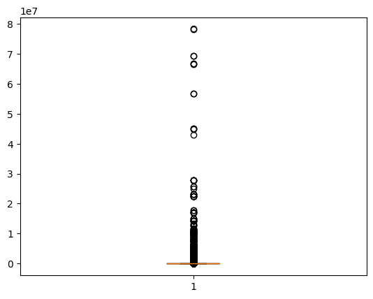

```python
# Check the presence of outliers in the column
plt.boxplot(data.Reviews)
```

```python
# Handle the outliers using a transformation approach
data.Reviews = np.log(data.Reviews)
```

```python
data.Reviews
```

```
0         5.068904
1         6.874198
2        11.379508
3        12.281384
4         6.874198
           ...
10834     1.945910
10836     3.637586
10837     1.386294
10839     4.736198
10840    12.894978
Name: Reviews, Length: 8886, dtype: float64
```

### 9. The column 'Size' contains alphanumeric values, treat the non numeric data and convert the column into suitable data type. (hint: Replace M with 1 million and K with 1 thousand, and drop the entries wheresize='Varies with device')

```python
# Replace M with 1 million and K with 1 thousand
data["Size"] = data["Size"].str.replace("M","000000")
```

```python
data["Size"]
```

```
0                  19000000
1                  14000000
2                 8.7000000
3                  25000000
4                 2.8000000
                ...
10834             2.6000000
10836              53000000
10837             3.6000000
10839    Varies with device
10840              19000000
Name: Size, Length: 8886, dtype: object
```

```python
data["Size"] = data["Size"].str.replace("k","000")
```

```python
data["Size"]
```

```
0                  19000000
1                  14000000
2                 8.7000000
3                  25000000
4                 2.8000000
                ...
10834             2.6000000
10836              53000000
10837             3.6000000
10839    Varies with device
10840              19000000
Name: Size, Length: 8886, dtype: object
```

```python
vwd = data[data["Size"] == "Varies with device"].index
```

```python
vwd
```

```
Int64Index([   37,    42,    52,    67,    68,    73,    85,    88,    89,
               92,
            ...
            10647, 10679, 10681, 10707, 10712, 10713, 10725, 10765, 10826,
            10839],
           dtype='int64', length=1468)
```

```python
data.drop(vwd,inplace=True)
```

```python
data.shape
```

```
(7418, 14)
```

### 10. Check the column 'Installs', treat the unwanted characters and convert the column into a suitable data type.

```python
# Replace '+' and ',' with empty string
data['Installs'] = data['Installs'].str.replace('+', '')
data['Installs'] = data['Installs'].str.replace(',', '')
```

```python
# Convert the column to int data type
data['Installs'] = data['Installs'].astype(int)
data['Installs']
```

```
0           10000
1          500000
2         5000000
3        50000000
4          100000
           ...
10833        1000
10834         500
10836        5000
10837         100
10840    10000000
Name: Installs, Length: 7418, dtype: int32
```

### 11. Check the column 'Price' , remove the unwanted characters and convert the column into a suitable data type.

```python
# Remove unwanted characters from the Price column
data.Price = data.Price.str.replace('$', '')
```

```python
data.Price
```

```
0        0
1        0
2        0
3        0
4        0
        ..
10833    0
10834    0
10836    0
10837    0
10840    0
Name: Price, Length: 7418, dtype: object
```

```python
# Convert the Price column to a suitable data type
data['Price'] = data['Price'].astype(float)
```

```python
data['Price']
```

```
0        0.0
1        0.0
2        0.0
3        0.0
4        0.0
        ...
10833    0.0
10834    0.0
10836    0.0
10837    0.0
10840    0.0
Name: Price, Length: 7418, dtype: float64
```

### 12. Drop the columns which you think redundant for the analysis.(suggestion: drop column 'rating', since we created a new feature from it (i.e. rating_category) and the columns 'App', 'Rating' ,'Genres','Last Updated','Current Ver','Android Ver' columns since which are redundant for our analysis)

```python
# Drop the columns which you think redundant for the analysis.
data = data.drop(columns=['Rating', 'App', 'Genres', 'Last Updated', 'Current Ver', 'Android Ver'])
```

```python
data
```

|  | Category | Reviews | Size | Installs | Type | Price | Content Rating | Rating_category |
| --- | --- | --- | --- | --- | --- | --- | --- | --- |
| 0 | ART_AND_DESIGN | 5.068904 | 19000000 | 10000 | Free | 0.0 | Everyone | High |
| 1 | ART_AND_DESIGN | 6.874198 | 14000000 | 500000 | Free | 0.0 | Everyone | Low |
| 2 | ART_AND_DESIGN | 11.379508 | 8.7000000 | 5000000 | Free | 0.0 | Everyone | High |
| 3 | ART_AND_DESIGN | 12.281384 | 25000000 | 50000000 | Free | 0.0 | Teen | High |
| 4 | ART_AND_DESIGN | 6.874198 | 2.8000000 | 100000 | Free | 0.0 | Everyone | High |
| ... | ... | ... | ... | ... | ... | ... | ... | ... |
| 10833 | BOOKS_AND_REFERENCE | 3.784190 | 619000 | 1000 | Free | 0.0 | Everyone | High |
| 10834 | FAMILY | 1.945910 | 2.6000000 | 500 | Free | 0.0 | Everyone | Low |
| 10836 | FAMILY | 3.637586 | 53000000 | 5000 | Free | 0.0 | Everyone | High |
| 10837 | FAMILY | 1.386294 | 3.6000000 | 100 | Free | 0.0 | Everyone | High |
| 10840 | LIFESTYLE | 12.894978 | 19000000 | 10000000 | Free | 0.0 | Everyone | High |

7418 rows × 8 columns

### 13. Encode the categorical columns.

```python
# Get list of categorical variables
s = (data.dtypes == 'object')
object_cols = list(s[s].index)
```

```python
# Print list of categorical variables
print("Categorical variables:")
print(object_cols)
```

```
Categorical variables:
['Category', 'Size', 'Type', 'Content Rating', 'Rating_category']
```

```python
from sklearn.preprocessing import LabelEncoder
labelencoder = LabelEncoder()
# Transforming the Category Column using Label Encoding.
data['Category'] = labelencoder.fit_transform(data['Category'])
```

```python
data['Category']
```

```
0         0
1         0
2         0
3         0
4         0
         ..
10833     3
10834    11
10836    11
10837    11
10840    18
Name: Category, Length: 7418, dtype: int32
```

```python
data['Size'] = labelencoder.fit_transform(data['Size'])
```

```python
data['Type'] = labelencoder.fit_transform(data['Type'])
```

```python
data['Content Rating'] = labelencoder.fit_transform(data['Content Rating'])
```

```python
data['Rating_category'] = labelencoder.fit_transform(data['Rating_category'])
```

### 14. Segregate the target and independent features (Hint: Use Rating_category as the target)

```python
target_feature = 'Rating_category'
independent_features = data.columns.drop(target_feature)
```

```python
independent_features
```

```
Index(['Category', 'Reviews', 'Size', 'Installs', 'Type', 'Price',
       'Content Rating'],
      dtype='object')
```

```python
# Create X and y dataframes
X = data[independent_features]
y = data[target_feature]
```

```python
X
```

|  | Category | Reviews | Size | Installs | Type | Price | Content Rating |
| --- | --- | --- | --- | --- | --- | --- | --- |
| 0 | 0 | 5.068904 | 44 | 10000 | 0 | 0.0 | 1 |
| 1 | 0 | 6.874198 | 22 | 500000 | 0 | 0.0 | 1 |
| 2 | 0 | 11.379508 | 333 | 5000000 | 0 | 0.0 | 1 |
| 3 | 0 | 12.281384 | 84 | 50000000 | 0 | 0.0 | 4 |
| 4 | 0 | 6.874198 | 56 | 100000 | 0 | 0.0 | 1 |
| ... | ... | ... | ... | ... | ... | ... | ... |
| 10833 | 3 | 3.784190 | 257 | 1000 | 0 | 0.0 | 1 |
| 10834 | 11 | 1.945910 | 54 | 500 | 0 | 0.0 | 1 |
| 10836 | 11 | 3.637586 | 217 | 5000 | 0 | 0.0 | 1 |
| 10837 | 11 | 1.386294 | 110 | 100 | 0 | 0.0 | 1 |
| 10840 | 18 | 12.894978 | 44 | 10000000 | 0 | 0.0 | 1 |

7418 rows × 7 columns

```python
y
```

```
0        0
1        1
2        0
3        0
4        0
        ..
10833    0
10834    1
10836    0
10837    0
10840    0
Name: Rating_category, Length: 7418, dtype: int32
```

### 15. Split the dataset into train and test.

```python
# Split the dataset into train and test
from sklearn.model_selection import train_test_split

X = data.drop(columns=['Content Rating']) # Features
y = data['Content Rating'] # Target variable
```

```python
X_train, X_test, y_train, y_test = train_test_split(X, y, test_size=0.2, random_state=1)
```

```python
X_train, X_test, y_train, y_test
```

```
(       Category    Reviews  Size  Installs  Type  Price  Rating_category
 4522         13   2.833213   105     10000     0    0.0                1
 7082          4   4.510860   328     10000     0    0.0                1
 729           8  10.224556    84   5000000     0    0.0                1
 10490        23   4.454347    36     10000     0    0.0                0
 506           7   4.653960    94      5000     0    0.0                1
 ...         ...        ...   ...       ...   ...    ...              ...
 1523         17  11.750855   259  10000000     0    0.0                1
 7763         29   8.862625    36   1000000     0    0.0                0
 5983         30   2.995732    26      1000     0    0.0                0
 349           6  10.315895    26   5000000     0    0.0                0
 7707         11   4.820282    53       500     0    0.0                0

 [5934 rows x 7 columns],
        Category    Reviews  Size   Installs  Type  Price  Rating_category
```

[output cut: 37 more lines]

### 16. Standardize the data, so that the values are within a particular range.

```python
# Standardize the data, so that the values are within a particular range
from sklearn.preprocessing import MinMaxScaler

# Create scaler object
scaler = MinMaxScaler()

# Fit and transform the dataframe
data_scaled = scaler.fit_transform(data)
```

```python
data_scaled
```

```
array([[0.        , 0.28768208, 0.10705596, ..., 0.        , 0.2       ,
        0.        ],
       [0.        , 0.39014028, 0.05352798, ..., 0.        , 0.2       ,
        1.        ],
       [0.        , 0.64583596, 0.81021898, ..., 0.        , 0.2       ,
        0.        ],
       ...,
       [0.34375   , 0.20644863, 0.52798054, ..., 0.        , 0.2       ,
        0.        ],
       [0.34375   , 0.07867816, 0.2676399 , ..., 0.        , 0.2       ,
        0.        ],
       [0.5625    , 0.73184539, 0.10705596, ..., 0.        , 0.2       ,
        0.        ]])
```